# Impact of temperature change on terrestrial vertebrates dynamics

Mathieu Pélissié, Maëlys Boënnec, Rémi Brosse

# Introduction

According to the latest WWF report, the average population size of terrestrial vertebrates has fallen by 68% In less than 50 years.<sup>1</sup> However, recent studies have even suggested that the dynamics of biodiversity are not really declining on average. They postulate that species at risk are dragging down global indices,<sup>2</sup> but that there are as many “winners” as “losers” species in total.<sup>3</sup> These last results have mainly been documented through the BioTIME database.<sup>4</sup> In this report, we propose to re-evaluate this through the Living Planet Database. We also aim to investigate whether population dynamics are influenced by minimal vs. maximal temperature change.

# Population changes

## Methods

The database considered contains 1212 species of terrestrial vertebrates and 5529 population time series distributed worldwide. We only focused on time series beginning after 1980 in order to be consistent with the climate data we analyse in the following part.

Each population time series was fitted with a linear regression model to quantify the trend through:

$$\begin{eqnarray*}
X(t) = \alpha_{0} + \alpha_{1}t + \epsilon(t)
\end{eqnarray*}$$

Where $X$ is the abundance estimate, $t$ the time in years, with process error represented by $\epsilon$ ~ $N$(0,$\sigma$²).

## Results

The following map illustrates the distribution of the time series. Each point is colored according to its trend and sized according to the magnitude of its trend.

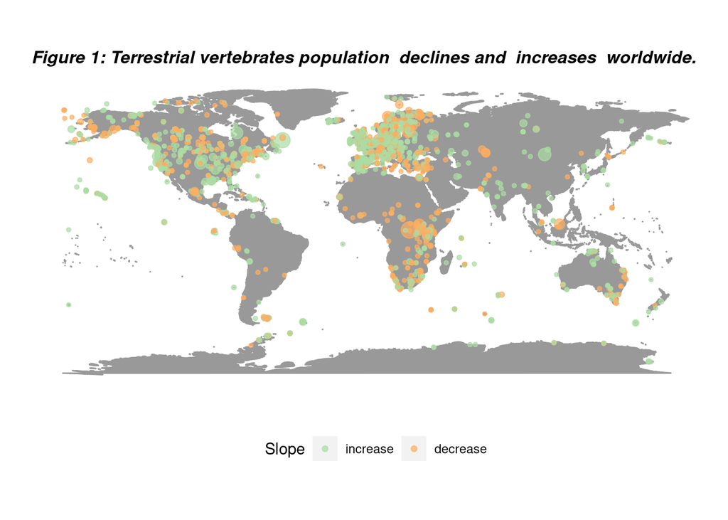

# Climate change data

## Methods

Worldwide minimum and maximum temperature averaged on a monthly basis were downloaded from the CHELSA climate database.<sup>5</sup> For each site with population survey, we focused on coldest minimal and hottest maximal temperatures by averaging the three lowest minimal and highest maximal month temperature values, respectively. This was done for the years 1980 and 2010 to distinguish potential effects of maximum vs. minimum temperature change.

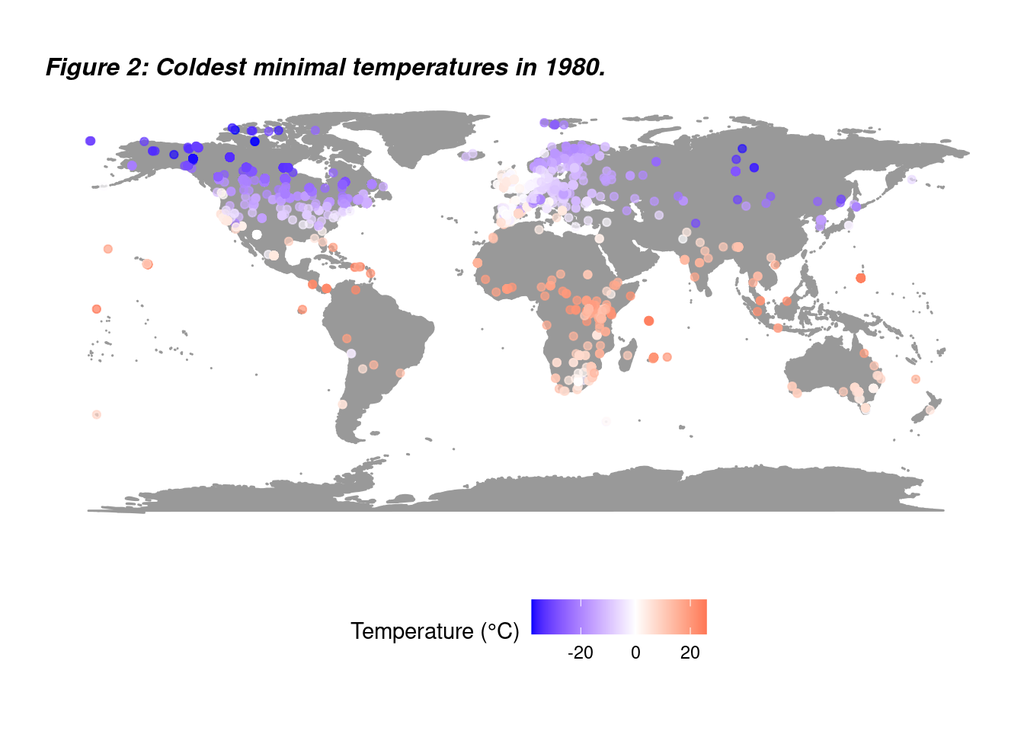

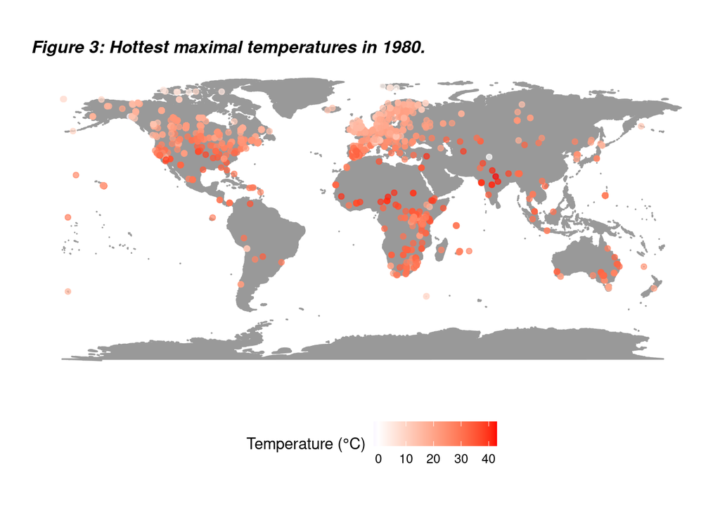

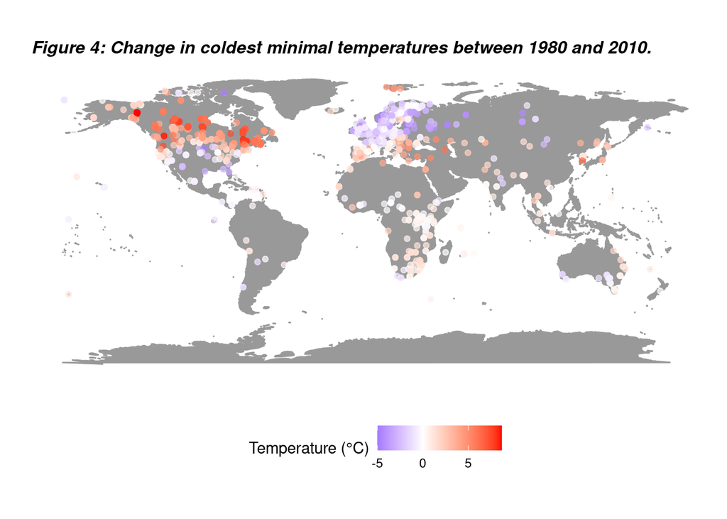

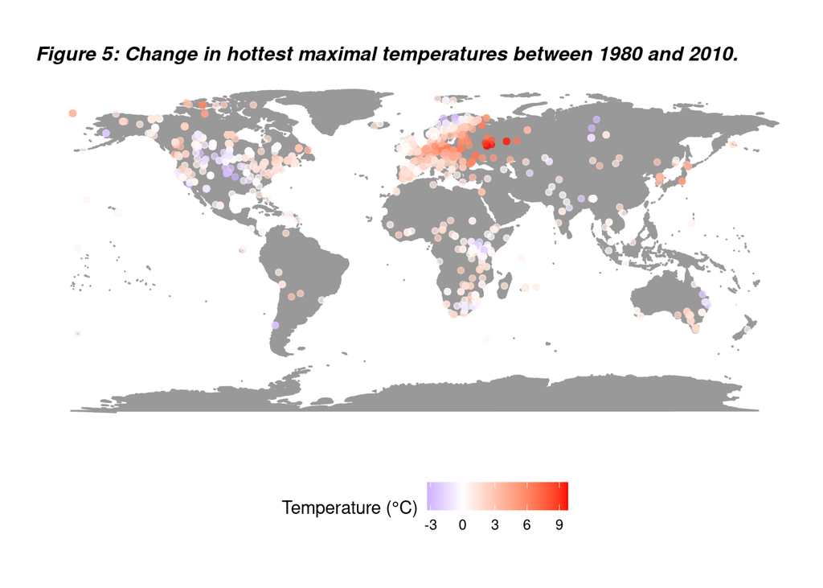

# Population change drivers

## Biogeographical drivers (biome and class impacts).

```
##
## Call:
## lm(formula = slope ~ biome, data = data_mod)
##
## Residuals:
##     Min      1Q  Median      3Q     Max
## -155523    -120     -97      92  125086
##
## Coefficients:
##                                                                        Estimate
## (Intercept)                                                              96.644
## biomeDeserts and xeric shrublands                                     -1150.856
## biomeFlooded grasslands and savannas                                    -90.600
## biomeLarge lakes                                                        -68.644
## biomeLarge river deltas                                               -1360.258
## biomeMediterranean forests woodlands and scrub                          -91.665
## biomeMontane freshwaters                                               -188.957
## biomeMontane grasslands and shrublands                                   77.689
## biomeOceanic islands                                                    -94.316
## biomePolar freshwaters                                                   15.542
## biomePolar seas                                                          66.562
## biomeTemperate broadleaf and mixed forests                             -188.266
## biomeTemperate coastal rivers                                           -89.611
## biomeTemperate coniferous forests                                         5.089
## biomeTemperate floodplain rivers and wetlands                           464.713
## biomeTemperate grasslands savannas and shrublands                       552.211
## biomeTemperate upland rivers                                           -142.670
## biomeTemperate upwelling                                               1971.947
## biomeTropical and subtropical coastal rivers                            -57.587
## biomeTropical and subtropical coniferous forests                        -89.984
## biomeTropical and subtropical dry broadleaf forests                    -118.387
## biomeTropical and subtropical floodplain rivers and wetland complexes -3651.598
## biomeTropical and subtropical grasslands savannas and shrublands       -727.695
## biomeTropical and subtropical moist broadleaf forests                  -471.877
## biomeTropical and subtropical upland rivers                             -98.359
## biomeTropical coral                                                     -10.610
## biomeTundra                                                             -36.187
## biomeUnknown                                                            108.522
## biomeXeric freshwaters and endorheic basins                           -1065.811
##                                                                       Std. Error
```

[output cut: 110 more lines]

```
## biomeTropical and subtropical dry broadleaf forests
## biomeTropical and subtropical floodplain rivers and wetland complexes ***
## biomeTropical and subtropical grasslands savannas and shrublands      *
## biomeTropical and subtropical moist broadleaf forests
## biomeTropical and subtropical upland rivers
## biomeTropical coral
## biomeTundra
## biomeUnknown
## biomeXeric freshwaters and endorheic basins
## ---
## Signif. codes:  0 '***' 0.001 '**' 0.01 '*' 0.05 '.' 0.1 ' ' 1
##
## Residual standard error: 4061 on 5206 degrees of freedom
## Multiple R-squared:  0.007326,   Adjusted R-squared:  0.001987
## F-statistic: 1.372 on 28 and 5206 DF,  p-value: 0.09153
```

## Climate change impacts

A multiple regression analysis was performed to determine whether some of the four temperature variables would be correlated with population trends. The results are presented below.

```
## Analysis of Variance Table
##
## Response: slope
##                    Df Sum Sq Mean Sq F value    Pr(>F)
## temp_diff_tasmax    1     21   20.58  0.1247    0.7240
## temp_diff_tasmin    1   2525 2525.14 15.3023 9.321e-05 ***
## mean_tasmax_2010    1    298  297.74  1.8043    0.1793
## mean_tasmin_2010    1     91   90.58  0.5489    0.4588
## Residuals        3794 626072  165.02
## ---
## Signif. codes:  0 '***' 0.001 '**' 0.01 '*' 0.05 '.' 0.1 ' ' 1
```

Although the rate of change in coldest minimal temperatures seems to have a negative effect on population trends, this effect is mainly driven by some extreme trends without which the interpretation of the results changes dramatically.

# References

1.

WWF. *Living Planet Report 2020 - Bending the curve of biodiversity loss. Almond, R.E.A., Grooten M. And Petersen, T. (Eds). WWF, Gland, Switzerland.* (2020).

2.

Leung, B. *et al.* Clustered versus catastrophic global vertebrate declines. *Nature* **588**, 267–271 (2020).

3.

Dornelas, M. *et al.* A balance of winners and losers in the Anthropocene. *Ecology Letters* **22**, 847–854 (2019).

4.

Dornelas, M. *et al.* BioTIME: A database of biodiversity time series for the Anthropocene. *Global Ecology and Biogeography* **27**, 760–786 (2018).

5.

Karger, D. N. *et al.* Climatologies at high resolution for the earth’s land surface areas. *Scientific Data* **4**, 170122 (2017).